# R Project

Maximilian Lorbiecki

October 19, 2016

### Setting up packages

```r
library(magrittr)
library(knitr)
library(plyr)
library(dplyr)
library(tidyr)
```

```r
library(ggplot2)
library(RColorBrewer)
library(car)
```

### Loading the data

```r
load("EdGenderWork.Rda")
```

```r
names(EdGenderWork)
```

```
##   [1] "psraid"     "sample"     "segment"    "int_date"   "lang"
##   [6] "comp"       "version"    "state"      "density"    "cregion"
##  [11] "usr"        "scregion"   "sstate"     "susr"       "igender"
##  [16] "irace"      "stimes"     "llitext"    "cpitext"    "lcb1"
##  [21] "lcb2"       "qs1"        "agesc"      "sex"        "q1"
##  [26] "q2a"        "q2b"        "q2c"        "q4"         "age"
##  [31] "educ2"      "ed1"        "ed2"        "schl"       "rschl"
##  [36] "schl2"      "schl2_orig" "q7a"        "q7b"        "q7c"
##  [41] "q7d"        "q7e"        "q8a"        "q8b"        "q8c"
##  [46] "q8d"        "q9"         "q10"        "q11"        "q12"
##  [51] "q13"        "q14"        "q15"        "q16"        "q17"
##  [56] "q17cd1"     "q17cd2"     "q18"        "q18cd1"     "q18cd2"
##  [61] "q19"        "q19cd1"     "q19cd2"     "q20"        "q21"
##  [66] "q22a"       "q22b"       "q22c"       "q22d"       "q23"
##  [71] "q24"        "qe3"        "qe3a"       "qd1"        "qd2"
```

[output cut: 22 more lines]

## Cleaning the data

Since we are only interested in the main interview questions we need to filter only the relavent datasets in our analysis. For now we will filter out all columns prior to column number 24 and all the columns after 162. Columns from 24 to 161 correlate to our main interview questions (24-161).

```r
EGW<-subset(EdGenderWork,select = c(24:161))
```

```r
names(EGW)
```

```
##   [1] "sex"        "q1"         "q2a"        "q2b"        "q2c"
##   [6] "q4"         "age"        "educ2"      "ed1"        "ed2"
##  [11] "schl"       "rschl"      "schl2"      "schl2_orig" "q7a"
##  [16] "q7b"        "q7c"        "q7d"        "q7e"        "q8a"
##  [21] "q8b"        "q8c"        "q8d"        "q9"         "q10"
##  [26] "q11"        "q12"        "q13"        "q14"        "q15"
##  [31] "q16"        "q17"        "q17cd1"     "q17cd2"     "q18"
##  [36] "q18cd1"     "q18cd2"     "q19"        "q19cd1"     "q19cd2"
##  [41] "q20"        "q21"        "q22a"       "q22b"       "q22c"
##  [46] "q22d"       "q23"        "q24"        "qe3"        "qe3a"
##  [51] "qd1"        "qd2"        "qd3"        "qd4a"       "qd4b"
##  [56] "qd4c"       "qe4"        "qe5"        "qe6"        "q28"
##  [61] "q29"        "q30a"       "q30b"       "q30c"       "q30d"
##  [66] "q30e"       "q30f"       "q30g"       "q31"        "qe7"
##  [71] "q34"        "q35"        "q36"        "q37"        "q40"
##  [76] "q41"        "q41cd1"     "q41cd2"     "q41cd3"     "marital"
##  [81] "lwp"        "qm2"        "q43"        "q44"        "q45"
##  [86] "q46"        "q47"        "q48"        "q49a"       "q49b"
##  [91] "q49c"       "q49d"       "q50"        "q51"        "q52"
##  [96] "kids1"      "kids2"      "kidsage"    "kids3"      "q54a"
## [101] "q54b"       "q55"        "q56a"       "q56b"       "q56c"
## [106] "q56d"       "q57a"       "q57b"       "q57c"       "q57d"
## [111] "q58a"       "q58b"       "q58c"       "q58d"       "hisp4"
## [116] "race3m1"    "race3m2"    "race3m3"    "race3m4"    "ownrent"
## [121] "relig"      "chr"        "born"       "attend"     "income"
## [126] "finan"      "party"      "partyln"    "ideo"       "birth_hisp"
## [131] "usborn1a"   "hh1"        "hh2"        "ql1"        "ql1a"
## [136] "qc1"        "ql2"        "ql3"
```

```r
head(EGW)
```

```
## # A tibble: 6 × 138
##     sex    q1   q2a   q2b   q2c    q4   age educ2   ed1   ed2  schl rschl
##   <dbl> <dbl> <dbl> <dbl> <dbl> <dbl> <dbl> <dbl> <dbl> <dbl> <dbl> <dbl>
## 1     2     3     1     4     5     1    71     4    NA    NA    NA    NA
## 2     1     1     1     9     5     3    87     4    NA    NA    NA    NA
## 3     2     2     1     2     3     3    53     6     1    NA     5     2
## 4     2     1     1     2     1     1    33     6     1    NA     5     3
## 5     1     2     1     2     2     1    52     6     1    NA     5     2
## 6     2     2     2     1     4     9    33     2    NA    NA     5     1
## # ... with 126 more variables: schl2 <dbl>, schl2_orig <dbl>, q7a <dbl>,
## #   q7b <dbl>, q7c <dbl>, q7d <dbl>, q7e <dbl>, q8a <dbl>, q8b <dbl>,
## #   q8c <dbl>, q8d <dbl>, q9 <dbl>, q10 <dbl>, q11 <dbl>, q12 <dbl>,
## #   q13 <dbl>, q14 <dbl>, q15 <dbl>, q16 <dbl>, q17 <dbl>, q17cd1 <dbl>,
## #   q17cd2 <dbl>, q18 <dbl>, q18cd1 <dbl>, q18cd2 <dbl>, q19 <dbl>,
## #   q19cd1 <dbl>, q19cd2 <dbl>, q20 <dbl>, q21 <dbl>, q22a <dbl>,
## #   q22b <dbl>, q22c <dbl>, q22d <dbl>, q23 <dbl>, q24 <dbl>, qe3 <dbl>,
## #   qe3a <dbl>, qd1 <dbl>, qd2 <dbl>, qd3 <dbl>, qd4a <dbl>, qd4b <dbl>,
## #   qd4c <dbl>, qe4 <dbl>, qe5 <dbl>, qe6 <dbl>, q28 <dbl>, q29 <dbl>,
## #   q30a <dbl>, q30b <dbl>, q30c <dbl>, q30d <dbl>, q30e <dbl>,
## #   q30f <dbl>, q30g <dbl>, q31 <dbl>, qe7 <dbl>, q34 <dbl>, q35 <dbl>,
## #   q36 <dbl>, q37 <dbl>, q40 <dbl>, q41 <dbl>, q41cd1 <dbl>,
## #   q41cd2 <dbl>, q41cd3 <dbl>, marital <dbl>, lwp <dbl>, qm2 <dbl>,
## #   q43 <dbl>, q44 <dbl>, q45 <dbl>, q46 <dbl>, q47 <dbl>, q48 <dbl>,
## #   q49a <dbl>, q49b <dbl>, q49c <dbl>, q49d <dbl>, q50 <dbl>, q51 <dbl>,
## #   q52 <dbl>, kids1 <dbl>, kids2 <dbl>, kidsage <dbl>, kids3 <dbl>,
## #   q54a <dbl>, q54b <dbl>, q55 <dbl>, q56a <dbl>, q56b <dbl>, q56c <dbl>,
## #   q56d <dbl>, q57a <dbl>, q57b <dbl>, q57c <dbl>, q57d <dbl>,
## #   q58a <dbl>, q58b <dbl>, ...
```

We can now see that column 1 (sex) represents the survey question asking about the sex of the participant on page 5 and column 138 (q13) represents the survey question asking about the whether calls are more likely on the cellphone or the homephone on page 26.

### Sex Variables and Societal Equality

The first questions that interests us is whether or not individuals who took the survey as a whole believe that society treats men or women equally, men over women, or women over men. This question is “q4” in our data.

```r
V1 <- EGW%>%group_by(q4) %>% summarise(count=length(q4))
head(V1)
```

```
## # A tibble: 4 × 2
##      q4 count
##   <dbl> <int>
## 1     1   780
## 2     2   174
## 3     3   924
## 4     9   124
```

Now that we have grouped the data to show how many answers there were for each question, lets change the numerical identifiers (1,2,3,and 9) into factoral questions such as “Equally,” “Women,” “Men,” and “Don’t know/Refuse.”

```r
V1$q4<-recode(V1$q4,"'1'='Equally'")
V1$q4<-recode(V1$q4,"'2'='Women'")
V1$q4<-recode(V1$q4,"'3'='Men'")
V1$q4<-recode(V1$q4,"'9'='NA'")
head(V1)
```

```
## # A tibble: 4 × 2
##        q4 count
##     <chr> <int>
## 1 Equally   780
## 2   Women   174
## 3     Men   924
## 4      NA   124
```

Now that the labels are written out, it is much easier to clearly see how many individuals chose which option for the questions on who society treats better. Lets graph this newly altered data.

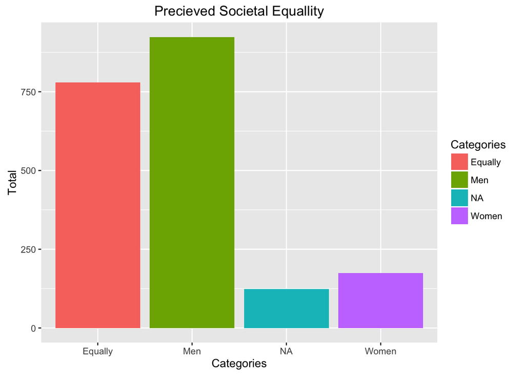

```r
ggplot(V1, aes(x=q4,y=count, fill=q4)) +
geom_bar(stat = "identity") +
labs(title = "Precieved Societal Equallity", y = "Total", x = "Categories", fill="Categories")
```

This is very interesting information, however a deeper question is present within the data. What factors may influence ones opinion on societies treatment of men and women? Is sex a factor to who you think society favors?

### Exploring Deeper

Before we begin our analysis, lets make sure we keep the variable names we created and apply it to our main dataset, EGW. While we are at it, lets change the sex to also indicate either male or female.

```r
EGW$q4<-recode(EGW$q4,"'1'='Equally'")
EGW$q4<-recode(EGW$q4,"'2'='Women'")
EGW$q4<-recode(EGW$q4,"'3'='Men'")
EGW$q4<-recode(EGW$q4,"'9'='NA'")

EGW$sex<-recode(EGW$sex, "'1'='Male'")
EGW$sex<-recode(EGW$sex, "'2'='Female'")
```

Now lets see if one’s sex is a strong determinant as to whether or not they think men or women are treated better. We first group this data into a new subset called “V2.”

```r
V2 <- EGW%>%group_by(q4, sex)
V2$q4 <- as.ordered(V2$q4)
V2$sex <- as.ordered(V2$sex)
head(V2)
```

```
## Source: local data frame [6 x 138]
## Groups: q4, sex [5]
##
##      sex    q1   q2a   q2b   q2c      q4   age educ2   ed1   ed2  schl
##    <ord> <dbl> <dbl> <dbl> <dbl>   <ord> <dbl> <dbl> <dbl> <dbl> <dbl>
## 1 Female     3     1     4     5 Equally    71     4    NA    NA    NA
## 2   Male     1     1     9     5     Men    87     4    NA    NA    NA
## 3 Female     2     1     2     3     Men    53     6     1    NA     5
## 4 Female     1     1     2     1 Equally    33     6     1    NA     5
## 5   Male     2     1     2     2 Equally    52     6     1    NA     5
## 6 Female     2     2     1     4      NA    33     2    NA    NA     5
## # ... with 127 more variables: rschl <dbl>, schl2 <dbl>, schl2_orig <dbl>,
## #   q7a <dbl>, q7b <dbl>, q7c <dbl>, q7d <dbl>, q7e <dbl>, q8a <dbl>,
## #   q8b <dbl>, q8c <dbl>, q8d <dbl>, q9 <dbl>, q10 <dbl>, q11 <dbl>,
## #   q12 <dbl>, q13 <dbl>, q14 <dbl>, q15 <dbl>, q16 <dbl>, q17 <dbl>,
## #   q17cd1 <dbl>, q17cd2 <dbl>, q18 <dbl>, q18cd1 <dbl>, q18cd2 <dbl>,
## #   q19 <dbl>, q19cd1 <dbl>, q19cd2 <dbl>, q20 <dbl>, q21 <dbl>,
## #   q22a <dbl>, q22b <dbl>, q22c <dbl>, q22d <dbl>, q23 <dbl>, q24 <dbl>,
## #   qe3 <dbl>, qe3a <dbl>, qd1 <dbl>, qd2 <dbl>, qd3 <dbl>, qd4a <dbl>,
## #   qd4b <dbl>, qd4c <dbl>, qe4 <dbl>, qe5 <dbl>, qe6 <dbl>, q28 <dbl>,
## #   q29 <dbl>, q30a <dbl>, q30b <dbl>, q30c <dbl>, q30d <dbl>, q30e <dbl>,
## #   q30f <dbl>, q30g <dbl>, q31 <dbl>, qe7 <dbl>, q34 <dbl>, q35 <dbl>,
## #   q36 <dbl>, q37 <dbl>, q40 <dbl>, q41 <dbl>, q41cd1 <dbl>,
## #   q41cd2 <dbl>, q41cd3 <dbl>, marital <dbl>, lwp <dbl>, qm2 <dbl>,
## #   q43 <dbl>, q44 <dbl>, q45 <dbl>, q46 <dbl>, q47 <dbl>, q48 <dbl>,
## #   q49a <dbl>, q49b <dbl>, q49c <dbl>, q49d <dbl>, q50 <dbl>, q51 <dbl>,
## #   q52 <dbl>, kids1 <dbl>, kids2 <dbl>, kidsage <dbl>, kids3 <dbl>,
## #   q54a <dbl>, q54b <dbl>, q55 <dbl>, q56a <dbl>, q56b <dbl>, q56c <dbl>,
## #   q56d <dbl>, q57a <dbl>, q57b <dbl>, q57c <dbl>, q57d <dbl>,
## #   q58a <dbl>, ...
```

Now that we have grouped the data by sex and the question we are interested in, let us create a visual from this and see if our question can be answered any further.

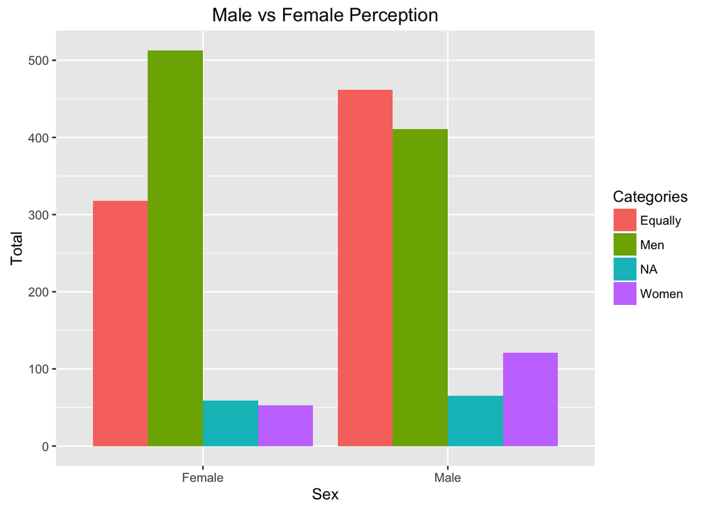

```r
ggplot(V2, aes(x=sex, fill=q4)) +
geom_bar(stat = "count", position="dodge") +
labs(title = "Male vs Female Perception", y = "Total", x = "Sex", fill="Categories")
```

From this visual, we can see that more females are likely to answer that men are treated greater in society. We also see that men have a higher tendency to answer that both sexes are treated equally when asked the same question. Females had a higher likelyhood of not responding to the question than responding with females being treated higher in society.

### Religous Variables and Societal Equality

This is very interesting information, but it would be interesting as well to see if religious preferences change ones view of society and its treatment towards the different sexes. Lets first start by changing our religious variables to the proper labels.

```r
EGW$relig<-recode(EGW$relig,"'1'='Protestant'")
EGW$relig<-recode(EGW$relig,"'2'='Roman Catholic'")
EGW$relig<-recode(EGW$relig,"'3'='Mormon'")
EGW$relig<-recode(EGW$relig,"'4'='Orthodox'")
EGW$relig<-recode(EGW$relig,"'5'='Jewish'")
EGW$relig<-recode(EGW$relig,"'6'='Muslim'")
EGW$relig<-recode(EGW$relig,"'7'='Buddhist'")
EGW$relig<-recode(EGW$relig,"'8'='Hindu'")
EGW$relig<-recode(EGW$relig,"'9'='Atheist'")
EGW$relig<-recode(EGW$relig,"'10'='Agnostic'")
EGW$relig<-recode(EGW$relig,"'11'='Something else'")
EGW$relig<-recode(EGW$relig,"'12'='Does not identifty'")
EGW$relig<-recode(EGW$relig,"'13'='Christian'")
EGW$relig<-recode(EGW$relig,"'14'='Unitarian'")
EGW$relig<-recode(EGW$relig,"'99'='Dont Know/Refused'")
```

Next lets group our data by religion and how the individual thought society treated men and women.

```r
V3 <- EGW%>%group_by(q4, relig)
V3$q4 <- as.ordered(V3$q4)
V3$relig <- as.factor(V3$relig)
head(V3)
```

```
## Source: local data frame [6 x 138]
## Groups: q4, relig [5]
##
##      sex    q1   q2a   q2b   q2c      q4   age educ2   ed1   ed2  schl
##    <chr> <dbl> <dbl> <dbl> <dbl>   <ord> <dbl> <dbl> <dbl> <dbl> <dbl>
## 1 Female     3     1     4     5 Equally    71     4    NA    NA    NA
## 2   Male     1     1     9     5     Men    87     4    NA    NA    NA
## 3 Female     2     1     2     3     Men    53     6     1    NA     5
## 4 Female     1     1     2     1 Equally    33     6     1    NA     5
## 5   Male     2     1     2     2 Equally    52     6     1    NA     5
## 6 Female     2     2     1     4      NA    33     2    NA    NA     5
## # ... with 127 more variables: rschl <dbl>, schl2 <dbl>, schl2_orig <dbl>,
## #   q7a <dbl>, q7b <dbl>, q7c <dbl>, q7d <dbl>, q7e <dbl>, q8a <dbl>,
## #   q8b <dbl>, q8c <dbl>, q8d <dbl>, q9 <dbl>, q10 <dbl>, q11 <dbl>,
## #   q12 <dbl>, q13 <dbl>, q14 <dbl>, q15 <dbl>, q16 <dbl>, q17 <dbl>,
## #   q17cd1 <dbl>, q17cd2 <dbl>, q18 <dbl>, q18cd1 <dbl>, q18cd2 <dbl>,
## #   q19 <dbl>, q19cd1 <dbl>, q19cd2 <dbl>, q20 <dbl>, q21 <dbl>,
## #   q22a <dbl>, q22b <dbl>, q22c <dbl>, q22d <dbl>, q23 <dbl>, q24 <dbl>,
## #   qe3 <dbl>, qe3a <dbl>, qd1 <dbl>, qd2 <dbl>, qd3 <dbl>, qd4a <dbl>,
## #   qd4b <dbl>, qd4c <dbl>, qe4 <dbl>, qe5 <dbl>, qe6 <dbl>, q28 <dbl>,
## #   q29 <dbl>, q30a <dbl>, q30b <dbl>, q30c <dbl>, q30d <dbl>, q30e <dbl>,
## #   q30f <dbl>, q30g <dbl>, q31 <dbl>, qe7 <dbl>, q34 <dbl>, q35 <dbl>,
## #   q36 <dbl>, q37 <dbl>, q40 <dbl>, q41 <dbl>, q41cd1 <dbl>,
## #   q41cd2 <dbl>, q41cd3 <dbl>, marital <dbl>, lwp <dbl>, qm2 <dbl>,
## #   q43 <dbl>, q44 <dbl>, q45 <dbl>, q46 <dbl>, q47 <dbl>, q48 <dbl>,
## #   q49a <dbl>, q49b <dbl>, q49c <dbl>, q49d <dbl>, q50 <dbl>, q51 <dbl>,
## #   q52 <dbl>, kids1 <dbl>, kids2 <dbl>, kidsage <dbl>, kids3 <dbl>,
## #   q54a <dbl>, q54b <dbl>, q55 <dbl>, q56a <dbl>, q56b <dbl>, q56c <dbl>,
## #   q56d <dbl>, q57a <dbl>, q57b <dbl>, q57c <dbl>, q57d <dbl>,
## #   q58a <dbl>, ...
```

Now that we have this data properly grouped. Lets graph this and see what our visualization looks like.

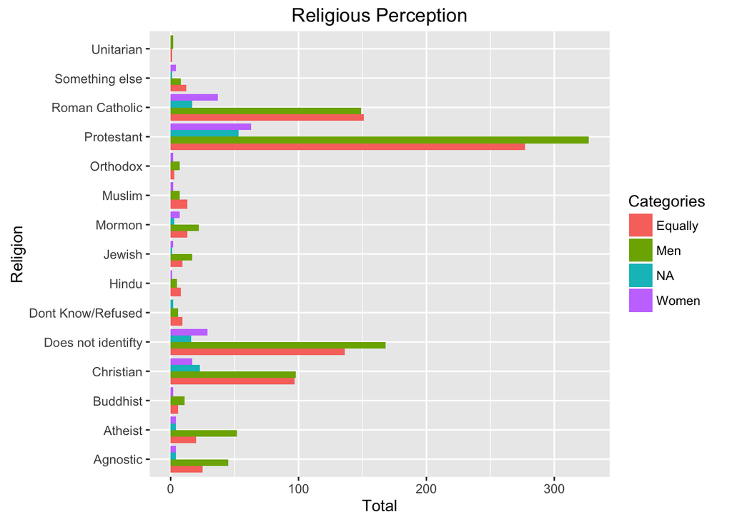

```r
ggplot(V3, aes(x=relig, fill=q4)) +
geom_bar(stat = "count", position="dodge") +
labs(title = "Religious Perception", y = "Total", x = "Religion", fill="Categories") + coord_flip()
```

As you can see our visualization is rather messy. We can manually reorder this data and try to graph this again. Lets order this in terms of how many participants there were. From this visual it is really hard to see how many individuals were in each religious group. In order to manually group them in order, we can use the table function to see what order we need to place them in.

```r
table(V3$relig)
```

```
##
##           Agnostic            Atheist           Buddhist
##                 78                 80                 19
##          Christian Does not identifty  Dont Know/Refused
##                235                349                 17
##              Hindu             Jewish             Mormon
##                 14                 29                 45
##             Muslim           Orthodox         Protestant
##                 22                 12                720
##     Roman Catholic     Something else          Unitarian
##                354                 25                  3
```

As you can see, the proper order is as follows: Protestant, Roman Catholic, Does not identify, Christian, Atheist, Agnostic, Mormon, Jewish, Something else, Muslim, Buddhist, Dont Know/Refuse, Hindu, Orthodox, and Unitarian. We will now manually reorder our list to represent this sample size.

```r
V3$relig <- factor(V3$relig,levels(V3$relig)[c(12,13,5,4,2,1,9,8,14,10,3,6,7,11,15)])
```

Now that we have reordered our religions, let us regraph our data.

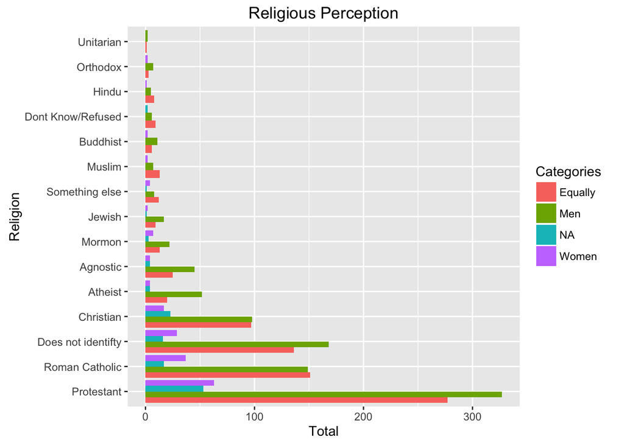

```r
ggplot(V3, aes(x=relig, fill=q4)) +
geom_bar(stat = "count", position="dodge") +
labs(title = "Religious Perception", y = "Total", x = "Religion", fill="Categories") + coord_flip()
```

With this new visual, we can see a few things very clearly. First off, our largest participating group is protestant participants, followed by the Roman Catholics, those who do not want to identify and finally Christians. Second, we can see that no group as a whole believes that women are more favorable than men in society or that women are more favorable than an equal society. Only five groups believed that society treated both groups equally more than men. Within these five groups, two of them were those who refused to answer and those who identified as something else. For the sake of looking specifically at religious groups and their perception on society’s treatment of men and women, we will look at the other three groups, Roman Catholics, Muslim, and Hindus, more closely.

### Sex and Religous Variables and Societal Equality

We will be taking a closer look at all three of the religions we have identified and see what portion of Females made up the answers provided. If Roman Catholic for example consisted of only men who chose the “equally” option and simply were a greater sample size then men, this could be misleading.

First let us look at the Roman Catholic distribution individualy.

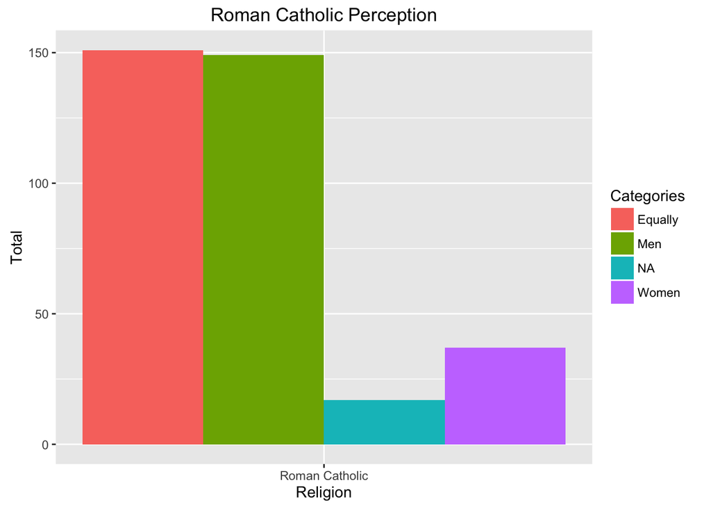

```r
ggplot(V3, aes(relig, fill=q4)) + geom_bar(data=subset(V3,relig=="Roman Catholic"),stat="count", position="dodge")+
  labs(title = "Roman Catholic Perception", y = "Total", x = "Religion", fill="Categories")
```

We can see from this visual that Roman Catholic participants favored equaly as an option over Men very slightly. Within the Roman Catholic group, it would be interesting to see how many Roman Catholic men chose the equally choice over women.

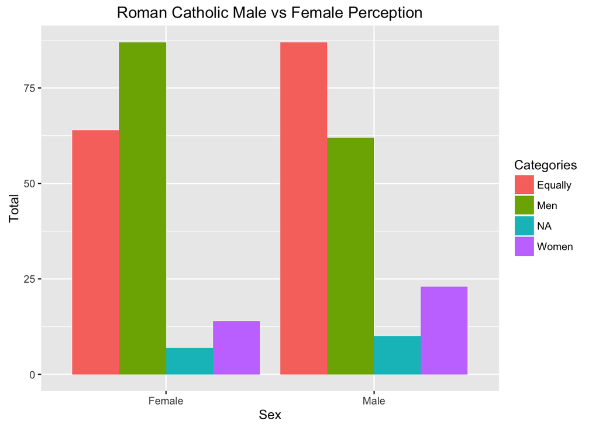

```r
ggplot(V3, aes(x=sex, fill=q4)) +
geom_bar(data=subset(V3,relig=="Roman Catholic"),stat = "count", position="dodge") +
labs(title = "Roman Catholic Male vs Female Perception", y = "Total", x = "Sex", fill="Categories")
```

The interesting thing to note in this case is that it was a majority of males within the Roman Catholic participant group, and not the females, who chose the equally option. Most women believed that men were suprior in society while most men believe that men and women were equals to eachother.

Next let us look at teh Muslim distribution individualy.

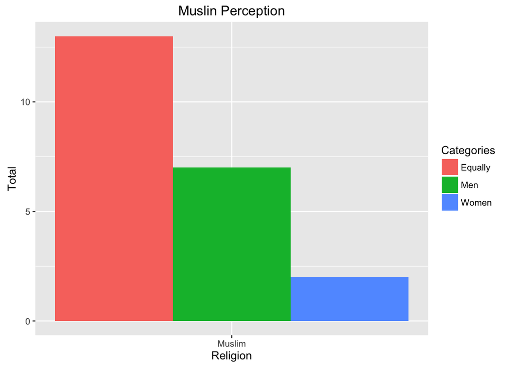

```r
ggplot(V3, aes(relig, fill=q4)) + geom_bar(data=subset(V3,relig=="Muslim"),stat="count", position="dodge")+
  labs(title = "Muslin Perception", y = "Total", x = "Religion", fill="Categories")
```

It is interesting in this case to see that Muslim participants where almost twice as likely to select equally as an option over men. Though this result is suprising, we can look again at the male and female distributions of the Muslim paticipants.

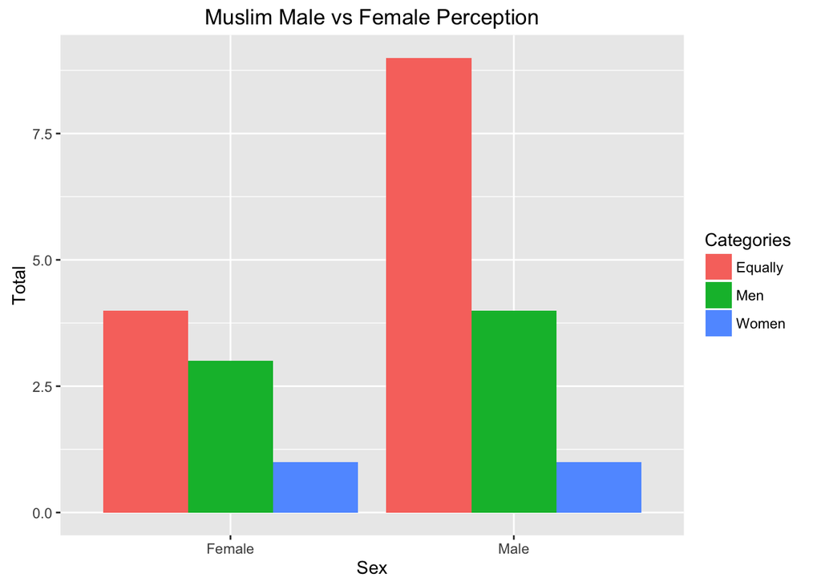

```r
ggplot(V3, aes(x=sex, fill=q4)) +
geom_bar(data=subset(V3,relig=="Muslim"),stat = "count", position="dodge") +
labs(title = "Muslim Male vs Female Perception", y = "Total", x = "Sex", fill="Categories")
```

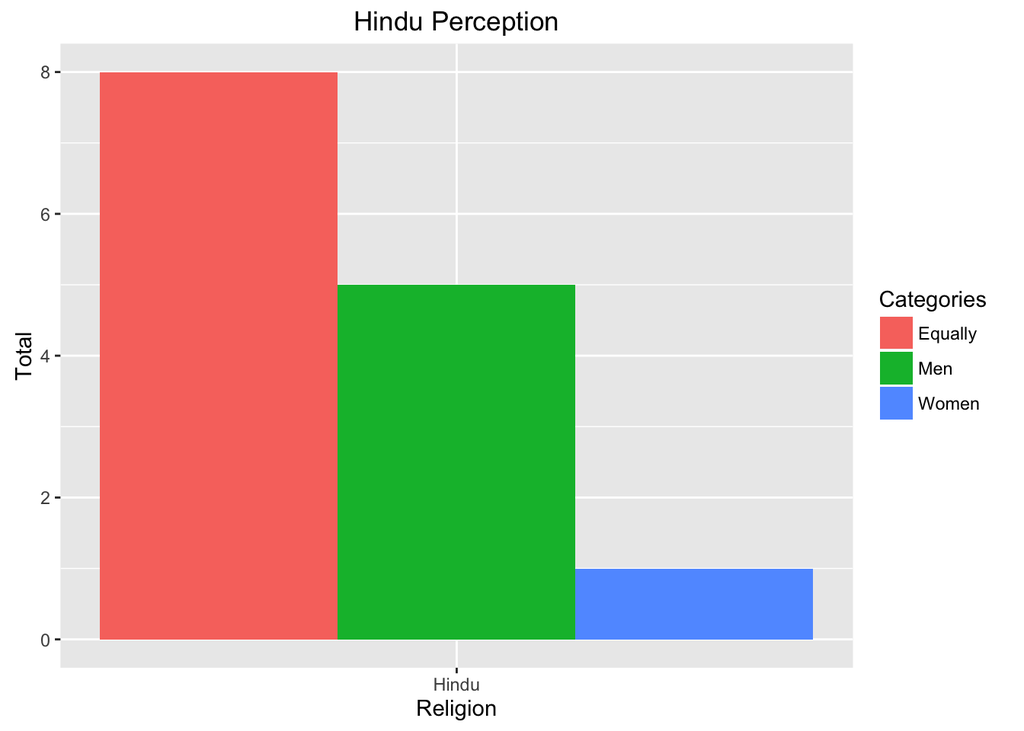

```r
ggplot(V3, aes(relig, fill=q4)) + geom_bar(data=subset(V3,relig=="Hindu"),stat="count", position="dodge")+
  labs(title = "Hindu Perception", y = "Total", x = "Religion", fill="Categories")
```

For the Hindu data, it is not quite as extreme as the Muslim data, but it does show that equally was selected by the Hindu participants much more often then the men option was selected. Again we will go one step deeper and see the male and female difference within the Hindu data set.

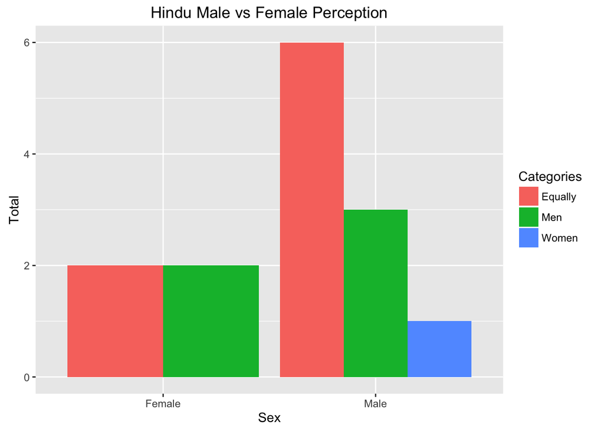

```r
ggplot(V3, aes(x=sex, fill=q4)) +
geom_bar(data=subset(V3,relig=="Hindu"),stat = "count", position="dodge") +
labs(title = "Hindu Male vs Female Perception", y = "Total", x = "Sex", fill="Categories")
```

Female Hindu participants were just as likely to select equally or men as their answer when participating in the survey. Men on the other hand were twice as likely to select equally over the men option when answering the survey.

In order to create a more focused analysis, we will exclude men from our analysis and look at what factors may be involved in women choosing “Equally” as a response to q4 over choosing “Men”.

### Isolating Females in our Data

q1 - The general happiness q2a - Family life satisfaction q2b - Financial satisfaction educ2 - Level of education qe3 - Employment status relig - Religion age - Age

To make our analysis easier, we will create a subset of data of only female particpants who answered “Equally” and female participants who answered “Men” for q4. For this first subset, lets create a group of all females.

```r
Females <- subset(EGW, sex == "Female",
select=c(q1,q2a,q2b,educ2,qe3,relig,age,q4))
head(Females)
```

```
## # A tibble: 6 × 8
##      q1   q2a   q2b educ2   qe3      relig   age      q4
##   <dbl> <dbl> <dbl> <dbl> <dbl>      <chr> <dbl>   <chr>
## 1     3     1     4     4     5 Protestant    71 Equally
## 2     2     1     2     6     2 Protestant    53     Men
## 3     1     1     2     6     1 Protestant    33 Equally
## 4     2     2     1     2     3 Protestant    33      NA
## 5     2     1     2     5     5 Protestant    79   Women
## 6     3     2     4     8     1    Atheist    42 Equally
```

Before we create a sub group which exludes those who answered anything different than “Equally” or “Men” let us recode the numeric responses so that we get a better understanding of what answers were submitted for our questions.

```r
Females$q1<-recode(Females$q1,"'1'='Very Happy'")
Females$q1<-recode(Females$q1,"'2'='Pretty Happy'")
Females$q1<-recode(Females$q1,"'3'='Not Too Happy'")
Females$q1<-recode(Females$q1,"'9'='Dont Know/Refuse'")
```

Next we recode q2a and q2b. Since both of these questions use the same values for their numbers, we can do this in one step.

```r
Females$q2a<-recode(Females$q2a,"'1'='Very Satisfied'")
Females$q2a<-recode(Females$q2a,"'2'='Somewhat Satisfied'")
Females$q2a<-recode(Females$q2a,"'3'='Somewhat Dissatisfied'")
Females$q2a<-recode(Females$q2a,"'4'='Very Dissatisfied'")
Females$q2a<-recode(Females$q2a,"'5'='Does Not Apply'")
Females$q2a<-recode(Females$q2a,"'9'='Dont Know/Refuse'")
Females$q2b<-recode(Females$q2b,"'1'='Very Satisfied'")
Females$q2b<-recode(Females$q2b,"'2'='Somewhat Satisfied'")
Females$q2b<-recode(Females$q2b,"'3'='Somewhat Dissatisfied'")
Females$q2b<-recode(Females$q2b,"'4'='Very Dissatisfied'")
Females$q2b<-recode(Females$q2b,"'5'='Does Not Apply'")
Females$q2b<-recode(Females$q2b,"'9'='Dont Know/Refuse'")
```

Next we recode educ2.

```r
Females$educ2<-recode(Females$educ2,"'1'='Less Than Highschool'")
Females$educ2<-recode(Females$educ2,"'2'='Highschool Incomplete'")
Females$educ2<-recode(Females$educ2,"'3'='Highschool Graduate'")
Females$educ2<-recode(Females$educ2,"'4'='Some College No Degree'")
Females$educ2<-recode(Females$educ2,"'5'='Associates Degree'")
Females$educ2<-recode(Females$educ2,"'6'='Bachelors Degree'")
Females$educ2<-recode(Females$educ2,"'7'='Some Postgraduate'")
Females$educ2<-recode(Females$educ2,"'8'='Postgraduate Degree'")
Females$educ2<-recode(Females$educ2,"'9'='Dont Know/Refuse'")
```

Lasty we recode qe3.

```r
Females$qe3<-recode(Females$qe3,"'1'='Full-time'")
Females$qe3<-recode(Females$qe3,"'2'='Part-time'")
Females$qe3<-recode(Females$qe3,"'3'='Not Employed'")
Females$qe3<-recode(Females$qe3,"'4'='Disabled'")
Females$qe3<-recode(Females$qe3,"'5'='Retired'")
Females$qe3<-recode(Females$qe3,"'9'='Dont Know/Refuse'")
```

Now that we have completed recoding the responses for our questions, we can create a new subgroup from “Females” which only includes those who responded “Equally” or “Men” for q4.

```r
MP <- subset(Females, q4 == "Equally" | q4 == "Men",
select=c(q1,q2a,q2b,educ2,qe3,relig,age,q4))
head(MP)
```

```
## # A tibble: 6 × 8
##              q1                q2a                   q2b
##           <chr>              <chr>                 <chr>
## 1 Not Too Happy     Very Satisfied     Very Dissatisfied
## 2  Pretty Happy     Very Satisfied    Somewhat Satisfied
## 3    Very Happy     Very Satisfied    Somewhat Satisfied
## 4 Not Too Happy Somewhat Satisfied     Very Dissatisfied
## 5    Very Happy     Very Satisfied        Very Satisfied
## 6  Pretty Happy     Very Satisfied Somewhat Dissatisfied
## # ... with 5 more variables: educ2 <chr>, qe3 <chr>, relig <chr>,
## #   age <dbl>, q4 <chr>
```

First lets try q1 which asks participants if they are happy in their life.

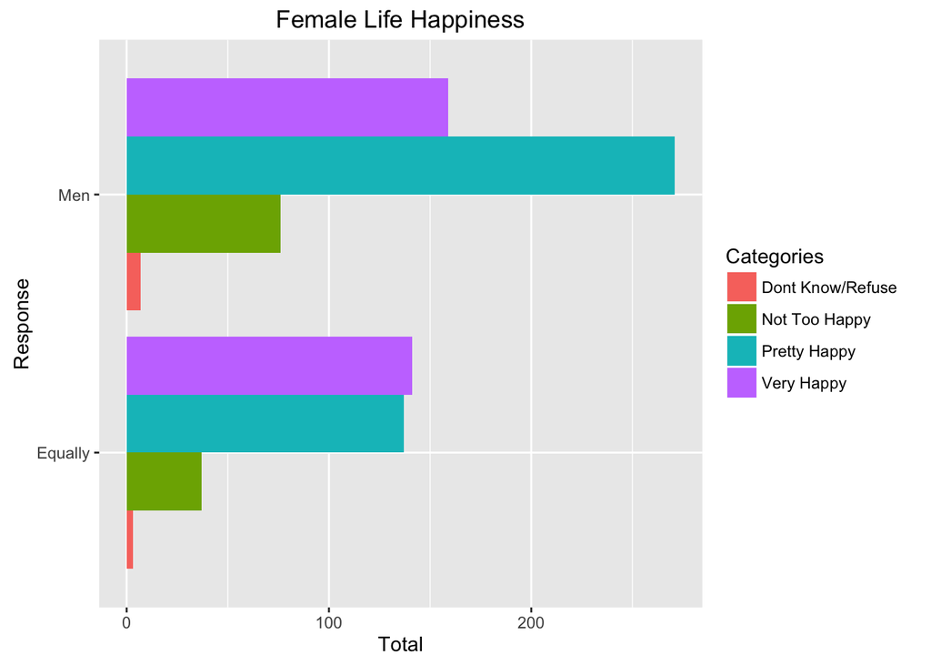

```r
ggplot(MP, aes(x=q4, fill=q1)) +
geom_bar(stat = "count", position="dodge") +
labs(title = "Female Life Happiness", y = "Total", x = "Response", fill="Categories") + coord_flip()
```

This graph does not seem to show too much of a difference between the two groups. Those who answered “men” had a higher number of participants respond with “Pretty Happy” compared to those who answered “equally”, however this could be simple sample size error.

We now look at q2a which is about happiness within the family.

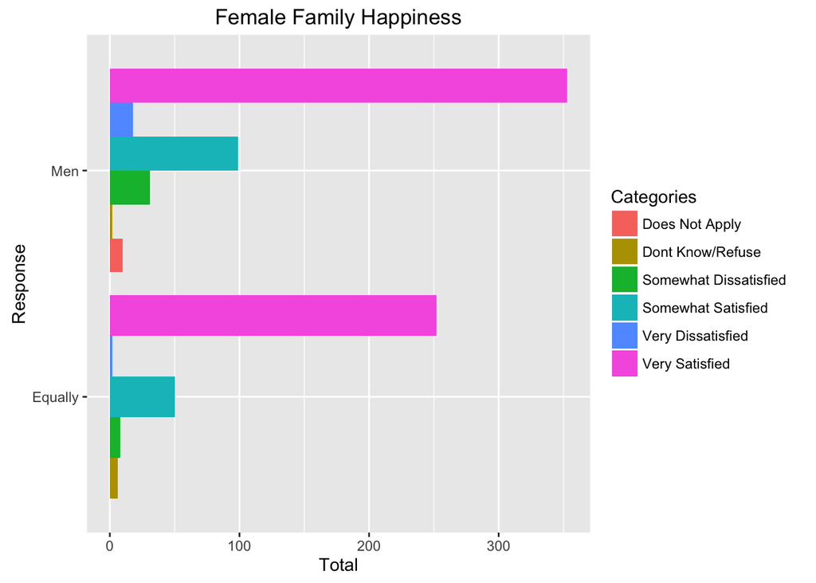

```r
ggplot(MP, aes(x=q4, fill=q2a)) +
geom_bar(stat = "count", position="dodge") +
labs(title = "Female Family Happiness", y = "Total", x = "Response", fill="Categories") + coord_flip()
```

This visual shows us a very interesting result. Scaled to size, it seems that hardly any participants who chose “equally” answered that they were very dissatisfied with their family. Those who responded “men” on the other hand had a small portion of participants answer that they were very disatisfied with their family. Though this is noticable, this may not be noticable enough to create a conclusion.

Next let us look at q2b which asks about financial satisfation.

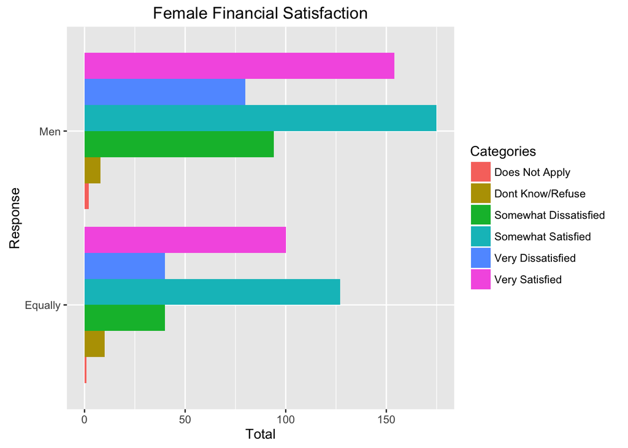

```r
ggplot(MP, aes(x=q4, fill=q2b)) +
geom_bar(stat = "count", position="dodge") +
labs(title = "Female Financial Satisfaction", y = "Total", x = "Response", fill="Categories") + coord_flip()
```

Again, what is unique here is that much like in the last visual, there is a much larger group of very dissatisfied participants in the “Men” group compared to the “Equally” group. This margin is alot more noticable compared to our last visual, however it is still not significant enough to reach a conclusion.

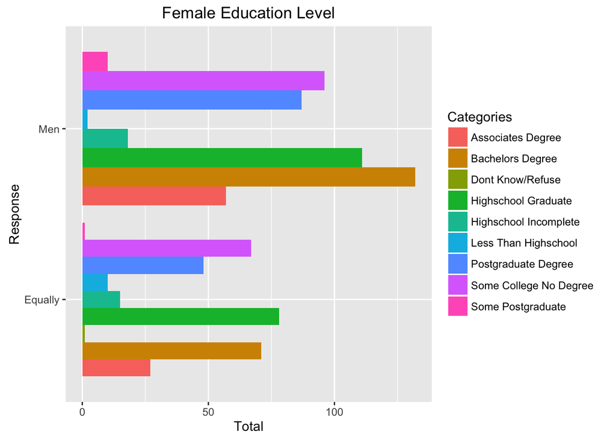

```r
ggplot(MP, aes(x=q4, fill=educ2)) +
geom_bar(stat = "count", position="dodge") +
labs(title = "Female Education Level", y = "Total", x = "Response", fill="Categories") + coord_flip()
```

In this visual we see that more of those who responded with “Equally” have completed a lower level of education compared to those who answered “Men”. Those who answered “Equally” have a larger group who had less than highschool levels of education than those who answered “Men” and much smaller groip of bachelors degrees than those who answered “Men”. This data seems to suggest that those who answered “Equally” had less education than those who answered “Men.”

We look at the employment status of our participants in qe3.

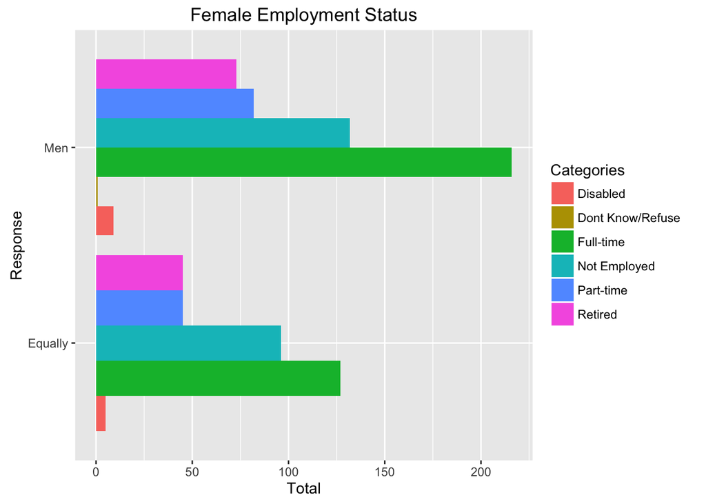

```r
ggplot(MP, aes(x=q4, fill=qe3)) +
geom_bar(stat = "count", position="dodge") +
labs(title = "Female Employment Status", y = "Total", x = "Response", fill="Categories") + coord_flip()
```

Scaled for sample size, these two visuals look relatively the same and seem to suggest that employment status is not a factor in our analysis.

This next factor is once again religion, however this time adjusted to only show female responses for “Equally” and “Men” in q4.

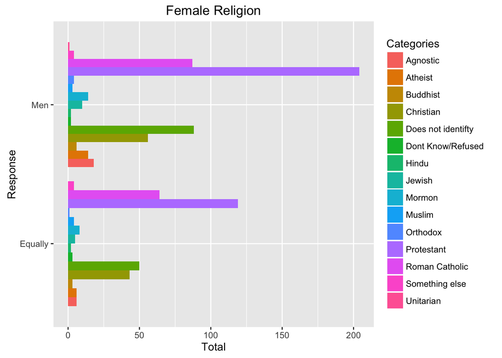

```r
ggplot(MP, aes(x=q4, fill=relig)) +
geom_bar(stat = "count", position="dodge") +
labs(title = "Female Religion", y = "Total", x = "Response", fill="Categories") + coord_flip()
```

In this visual, it is important to compare the two groups by eachother. We see that only Females who identified as Muslim or Those who did not know or refused chose the “Equally” option over “Men”.

In our last factor we will be looking at whether the age of the individual correlates to choosing “Men” or “Equally” for q4.

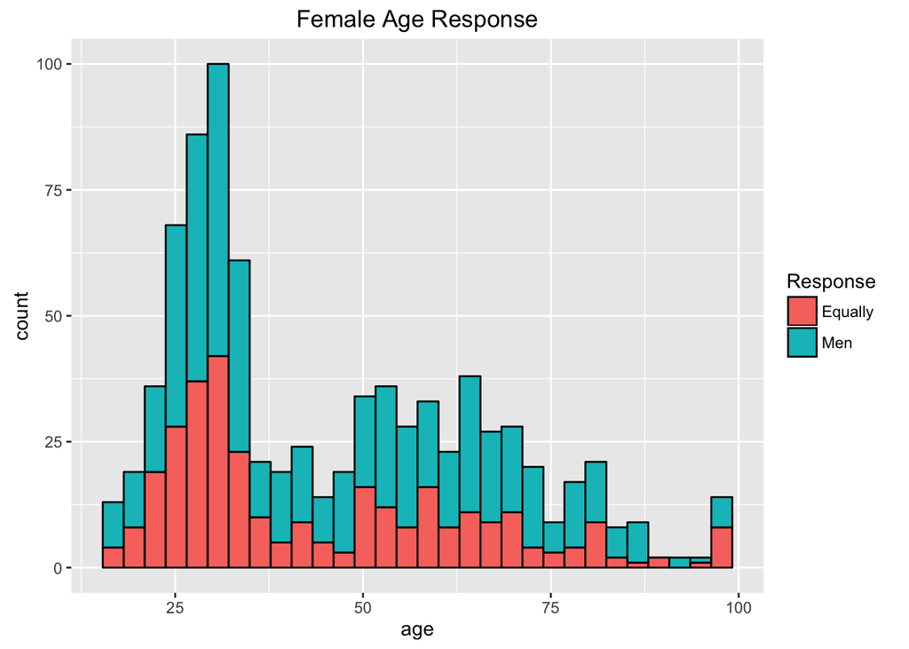

```r
ggplot(MP, aes(x = age))+geom_histogram( aes(fill = q4), color="black") +
labs(title = "Female Age Response",fill="Response")
```

### Conclusion

In our analysis we tried to analyse the factors that might cause a Female participant to respond that Men and Women are treated equally in society over the most common answer, that Men are favored over Women in society.

Through our analysis, we discoved that both the factors of age and employment status of the participant are low, if not completely unrelated, to their view on societal equality.

Muslim women and those women who refused to answer about their religion had the highest chance of selecting equally when asked about societal equality.

There was a slight trend that those who answered that society treated men and women equally had a lower level of education compared to those who said than men were favored in society.

There were no profound difference in any of the questions analyzed between the two groups. In future analysis of this data, it would be interesting to compare those who answered “Women” and those who answered “Men” in the question regarding societal equality.